# Predicting West Nile Virus - Kaggle Competition

```python
import pandas as pd
from matplotlib import pyplot as plt
import numpy as np
# pip install pandas-profiling
import pandas_profiling as pdp
import seaborn as sns
%matplotlib inline
import time
import datetime

traps = pd.read_csv('assets/train.csv')
test = pd.read_csv('assets/test.csv')
spray = pd.read_csv('assets/spray.csv')
weather = pd.read_csv('assets/weather.csv')
```

# EDA

## Traps

Overview

Dataset info

| Number of variables | 12 |
| --- | --- |
| Number of observations | 10506 |
| Total Missing (%) | 0.0% |
| Total size in memory | 985.0 KiB |
| Average record size in memory | 96.0 B |

Variables types

| Numeric | 6 |
| --- | --- |
| Categorical | 6 |
| Date | 0 |
| Text (Unique) | 0 |
| Rejected | 0 |

Warnings

- `Address` has a high cardinality: 138 distinct values Warning

- `AddressNumberAndStreet` has a high cardinality: 138 distinct values Warning

- `Date` has a high cardinality: 95 distinct values Warning

- `Street` has a high cardinality: 128 distinct values Warning

- `Trap` has a high cardinality: 136 distinct values Warning

- `WnvPresent` has 9955 / 94.8% zeros

- Dataset has 813 duplicate rows Warning

Variables

Address  
Categorical

| Distinct count | 138 |
| --- | --- |
| Unique (%) | 1.3% |
| Missing (%) | 0.0% |
| Missing (n) | 0 |

| ORD Terminal 5, O'Hare International Airport, Chicago, IL 60666, USA | 750 |
| --- | --- |
| South Doty Avenue, Chicago, IL, USA | 542 |
| South Stony Island Avenue, Chicago, IL, USA | 314 |
| Other values (135) | 8900 |

Toggle details

| Value | Count | Frequency (%) |  |
| --- | --- | --- | --- |
| ORD Terminal 5, O'Hare International Airport, Chicago, IL 60666, USA | 750 | 7.1% |  |
| South Doty Avenue, Chicago, IL, USA | 542 | 5.2% |  |
| South Stony Island Avenue, Chicago, IL, USA | 314 | 3.0% |  |
| 4100 North Oak Park Avenue, Chicago, IL 60634, USA | 185 | 1.8% |  |
| 4200 West 127th Street, Alsip, IL 60803, USA | 183 | 1.7% |  |
| 2200 North Cannon Drive, Chicago, IL 60614, USA | 163 | 1.6% |  |
| 2400 East 105th Street, Chicago, IL 60617, USA | 160 | 1.5% |  |
| 7000 West Armitage Avenue, Chicago, IL 60707, USA | 156 | 1.5% |  |
| 3700 118th Street, Chicago, IL 60617, USA | 152 | 1.4% |  |
| University of Illinois at Chicago, 1100 South Ashland Avenue, Chicago, IL 60607, USA | 151 | 1.4% |  |
| Other values (128) | 7750 | 73.8% |  |

AddressAccuracy  
Numeric

| Distinct count | 4 |
| --- | --- |
| Unique (%) | 0.0% |
| Missing (%) | 0.0% |
| Missing (n) | 0 |
| Infinite (%) | 0.0% |
| Infinite (n) | 0 |

| Mean | 7.8195 |
| --- | --- |
| Minimum | 3 |
| Maximum | 9 |
| Zeros (%) | 0.0% |

Toggle details

**Statistics**

Quantile statistics

| Minimum | 3 |
| --- | --- |
| 5-th percentile | 5 |
| Q1 | 8 |
| Median | 8 |
| Q3 | 9 |
| 95-th percentile | 9 |
| Maximum | 9 |
| Range | 6 |
| Interquartile range | 1 |

Descriptive statistics

| Standard deviation | 1.4529 |
| --- | --- |
| Coef of variation | 0.18581 |
| Kurtosis | 0.65475 |
| Mean | 7.8195 |
| MAD | 1.0534 |
| Skewness | -1.3695 |
| Sum | 82152 |
| Variance | 2.111 |
| Memory size | 82.1 KiB |

**Histogram**

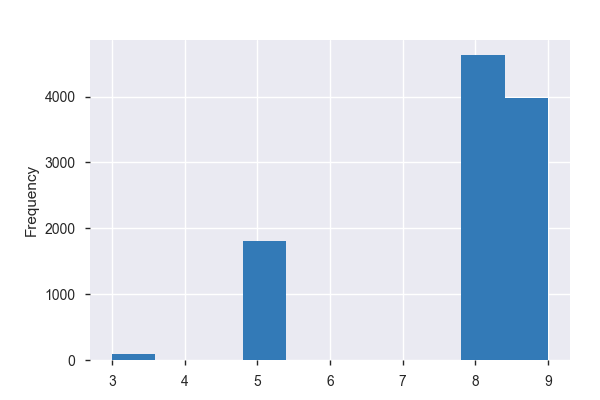

**Common Values**

| Value | Count | Frequency (%) |  |
| --- | --- | --- | --- |
| 8 | 4628 | 44.1% |  |
| 9 | 3980 | 37.9% |  |
| 5 | 1807 | 17.2% |  |
| 3 | 91 | 0.9% |  |

**Extreme Values**

Minimum 5 values

| Value | Count | Frequency (%) |  |
| --- | --- | --- | --- |
| 3 | 91 | 0.9% |  |
| 5 | 1807 | 17.2% |  |
| 8 | 4628 | 44.1% |  |
| 9 | 3980 | 37.9% |  |

Maximum 5 values

| Value | Count | Frequency (%) |  |
| --- | --- | --- | --- |
| 3 | 91 | 0.9% |  |
| 5 | 1807 | 17.2% |  |
| 8 | 4628 | 44.1% |  |
| 9 | 3980 | 37.9% |  |

AddressNumberAndStreet  
Categorical

| Distinct count | 138 |
| --- | --- |
| Unique (%) | 1.3% |
| Missing (%) | 0.0% |
| Missing (n) | 0 |

| 1000 W OHARE AIRPORT, Chicago, IL | 750 |
| --- | --- |
| 1200 S DOTY AVE, Chicago, IL | 542 |
| 1000 S STONY ISLAND AVE, Chicago, IL | 314 |
| Other values (135) | 8900 |

Toggle details

| Value | Count | Frequency (%) |  |
| --- | --- | --- | --- |
| 1000 W OHARE AIRPORT, Chicago, IL | 750 | 7.1% |  |
| 1200 S DOTY AVE, Chicago, IL | 542 | 5.2% |  |
| 1000 S STONY ISLAND AVE, Chicago, IL | 314 | 3.0% |  |
| 4100 N OAK PARK AVE, Chicago, IL | 185 | 1.8% |  |
| 4200 W 127TH PL, Chicago, IL | 183 | 1.7% |  |
| 2200 N CANNON DR, Chicago, IL | 163 | 1.6% |  |
| 2400 E 105TH ST, Chicago, IL | 160 | 1.5% |  |
| 7000 W ARMITAGE AVENUE, Chicago, IL | 156 | 1.5% |  |
| 3700 E 118TH ST, Chicago, IL | 152 | 1.4% |  |
| 1100 S ASHLAND AVE, Chicago, IL | 151 | 1.4% |  |
| Other values (128) | 7750 | 73.8% |  |

Block  
Numeric

| Distinct count | 64 |
| --- | --- |
| Unique (%) | 0.6% |
| Missing (%) | 0.0% |
| Missing (n) | 0 |
| Infinite (%) | 0.0% |
| Infinite (n) | 0 |

| Mean | 35.688 |
| --- | --- |
| Minimum | 10 |
| Maximum | 98 |
| Zeros (%) | 0.0% |

Toggle details

**Statistics**

Quantile statistics

| Minimum | 10 |
| --- | --- |
| 5-th percentile | 10 |
| Q1 | 12 |
| Median | 33 |
| Q3 | 52 |
| 95-th percentile | 82 |
| Maximum | 98 |
| Range | 88 |
| Interquartile range | 40 |

Descriptive statistics

| Standard deviation | 24.339 |
| --- | --- |
| Coef of variation | 0.68201 |
| Kurtosis | -0.73761 |
| Mean | 35.688 |
| MAD | 20.794 |
| Skewness | 0.62672 |
| Sum | 374936 |
| Variance | 592.41 |
| Memory size | 82.1 KiB |

**Histogram**

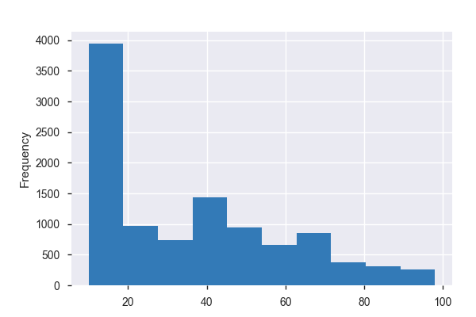

**Common Values**

| Value | Count | Frequency (%) |  |
| --- | --- | --- | --- |
| 10 | 1722 | 16.4% |  |
| 11 | 736 | 7.0% |  |
| 12 | 605 | 5.8% |  |
| 22 | 500 | 4.8% |  |
| 13 | 345 | 3.3% |  |
| 37 | 330 | 3.1% |  |
| 17 | 305 | 2.9% |  |
| 42 | 300 | 2.9% |  |
| 70 | 295 | 2.8% |  |
| 52 | 277 | 2.6% |  |
| Other values (54) | 5091 | 48.5% |  |

**Extreme Values**

Minimum 5 values

| Value | Count | Frequency (%) |  |
| --- | --- | --- | --- |
| 10 | 1722 | 16.4% |  |
| 11 | 736 | 7.0% |  |
| 12 | 605 | 5.8% |  |
| 13 | 345 | 3.3% |  |
| 14 | 97 | 0.9% |  |

Maximum 5 values

| Value | Count | Frequency (%) |  |
| --- | --- | --- | --- |
| 90 | 77 | 0.7% |  |
| 91 | 111 | 1.1% |  |
| 93 | 21 | 0.2% |  |
| 96 | 31 | 0.3% |  |
| 98 | 23 | 0.2% |  |

Date  
Categorical

| Distinct count | 95 |
| --- | --- |
| Unique (%) | 0.9% |
| Missing (%) | 0.0% |
| Missing (n) | 0 |

| 2007-08-01 | 551 |
| --- | --- |
| 2007-08-15 | 276 |
| 2013-08-01 | 186 |
| Other values (92) | 9493 |

Toggle details

| Value | Count | Frequency (%) |  |
| --- | --- | --- | --- |
| 2007-08-01 | 551 | 5.2% |  |
| 2007-08-15 | 276 | 2.6% |  |
| 2013-08-01 | 186 | 1.8% |  |
| 2007-08-24 | 186 | 1.8% |  |
| 2007-08-21 | 186 | 1.8% |  |
| 2007-10-04 | 185 | 1.8% |  |
| 2007-08-07 | 184 | 1.8% |  |
| 2013-07-12 | 182 | 1.7% |  |
| 2013-07-19 | 182 | 1.7% |  |
| 2013-08-08 | 181 | 1.7% |  |
| Other values (85) | 8207 | 78.1% |  |

Latitude  
Numeric

| Distinct count | 138 |
| --- | --- |
| Unique (%) | 1.3% |
| Missing (%) | 0.0% |
| Missing (n) | 0 |
| Infinite (%) | 0.0% |
| Infinite (n) | 0 |

| Mean | 41.841 |
| --- | --- |
| Minimum | 41.645 |
| Maximum | 42.017 |
| Zeros (%) | 0.0% |

Toggle details

**Statistics**

Quantile statistics

| Minimum | 41.645 |
| --- | --- |
| 5-th percentile | 41.673 |
| Q1 | 41.733 |
| Median | 41.846 |
| Q3 | 41.955 |
| 95-th percentile | 41.992 |
| Maximum | 42.017 |
| Range | 0.37282 |
| Interquartile range | 0.22171 |

Descriptive statistics

| Standard deviation | 0.11274 |
| --- | --- |
| Coef of variation | 0.0026945 |
| Kurtosis | -1.4402 |
| Mean | 41.841 |
| MAD | 0.10219 |
| Skewness | -0.08944 |
| Sum | 439580 |
| Variance | 0.012711 |
| Memory size | 82.1 KiB |

**Histogram**

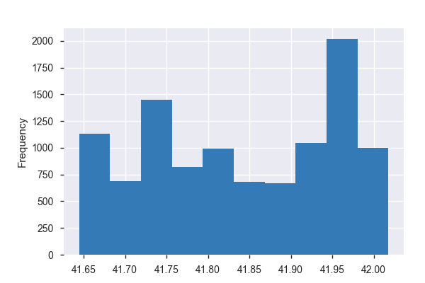

**Common Values**

| Value | Count | Frequency (%) |  |
| --- | --- | --- | --- |
| 41.974689 | 750 | 7.1% |  |
| 41.673408 | 542 | 5.2% |  |
| 41.726465 | 314 | 3.0% |  |
| 41.95469 | 185 | 1.8% |  |
| 41.662014 | 183 | 1.7% |  |
| 41.921965 | 163 | 1.6% |  |
| 41.704572 | 160 | 1.5% |  |
| 41.916265 | 156 | 1.5% |  |
| 41.680946 | 152 | 1.4% |  |
| 41.868077 | 151 | 1.4% |  |
| Other values (128) | 7750 | 73.8% |  |

**Extreme Values**

Minimum 5 values

| Value | Count | Frequency (%) |  |
| --- | --- | --- | --- |
| 41.644612 | 17 | 0.2% |  |
| 41.659112 | 112 | 1.1% |  |
| 41.662014 | 183 | 1.7% |  |
| 41.673408 | 542 | 5.2% |  |
| 41.678618 | 129 | 1.2% |  |

Maximum 5 values

| Value | Count | Frequency (%) |  |
| --- | --- | --- | --- |
| 42.008314 | 139 | 1.3% |  |
| 42.009876 | 50 | 0.5% |  |
| 42.010412 | 63 | 0.6% |  |
| 42.011601 | 66 | 0.6% |  |
| 42.01743 | 69 | 0.7% |  |

Longitude  
Numeric

| Distinct count | 138 |
| --- | --- |
| Unique (%) | 1.3% |
| Missing (%) | 0.0% |
| Missing (n) | 0 |
| Infinite (%) | 0.0% |
| Infinite (n) | 0 |

| Mean | -87.7 |
| --- | --- |
| Minimum | -87.931 |
| Maximum | -87.532 |
| Zeros (%) | 0.0% |

Toggle details

**Statistics**

Quantile statistics

| Minimum | -87.931 |
| --- | --- |
| 5-th percentile | -87.891 |
| Q1 | -87.76 |
| Median | -87.695 |
| Q3 | -87.628 |
| 95-th percentile | -87.547 |
| Maximum | -87.532 |
| Range | 0.39936 |
| Interquartile range | 0.13227 |

Descriptive statistics

| Standard deviation | 0.096514 |
| --- | --- |
| Coef of variation | -0.0011005 |
| Kurtosis | -0.43627 |
| Mean | -87.7 |
| MAD | 0.077598 |
| Skewness | -0.37028 |
| Sum | -921380 |
| Variance | 0.009315 |
| Memory size | 82.1 KiB |

**Histogram**

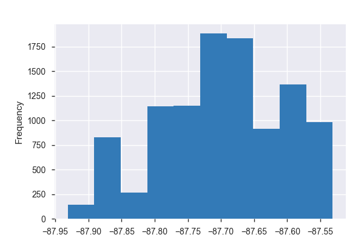

**Common Values**

| Value | Count | Frequency (%) |  |
| --- | --- | --- | --- |
| -87.890615 | 750 | 7.1% |  |
| -87.599862 | 542 | 5.2% |  |
| -87.585413 | 314 | 3.0% |  |
| -87.800991 | 185 | 1.8% |  |
| -87.724608 | 183 | 1.7% |  |
| -87.632085 | 163 | 1.6% |  |
| -87.565666 | 160 | 1.5% |  |
| -87.800515 | 156 | 1.5% |  |
| -87.535198 | 152 | 1.4% |  |
| -87.666901 | 151 | 1.4% |  |
| Other values (128) | 7750 | 73.8% |  |

**Extreme Values**

Minimum 5 values

| Value | Count | Frequency (%) |  |
| --- | --- | --- | --- |
| -87.930995 | 140 | 1.3% |  |
| -87.890615 | 750 | 7.1% |  |
| -87.862995 | 80 | 0.8% |  |
| -87.832763 | 133 | 1.3% |  |
| -87.824812 | 35 | 0.3% |  |

Maximum 5 values

| Value | Count | Frequency (%) |  |
| --- | --- | --- | --- |
| -87.538693 | 112 | 1.1% |  |
| -87.536497 | 83 | 0.8% |  |
| -87.535198 | 152 | 1.4% |  |
| -87.531657 | 23 | 0.2% |  |
| -87.531635 | 45 | 0.4% |  |

NumMosquitos  
Numeric

| Distinct count | 50 |
| --- | --- |
| Unique (%) | 0.5% |
| Missing (%) | 0.0% |
| Missing (n) | 0 |
| Infinite (%) | 0.0% |
| Infinite (n) | 0 |

| Mean | 12.854 |
| --- | --- |
| Minimum | 1 |
| Maximum | 50 |
| Zeros (%) | 0.0% |

Toggle details

**Statistics**

Quantile statistics

| Minimum | 1 |
| --- | --- |
| 5-th percentile | 1 |
| Q1 | 2 |
| Median | 5 |
| Q3 | 17 |
| 95-th percentile | 50 |
| Maximum | 50 |
| Range | 49 |
| Interquartile range | 15 |

Descriptive statistics

| Standard deviation | 16.134 |
| --- | --- |
| Coef of variation | 1.2552 |
| Kurtosis | 0.5224 |
| Mean | 12.854 |
| MAD | 12.778 |
| Skewness | 1.4049 |
| Sum | 135039 |
| Variance | 260.3 |
| Memory size | 82.1 KiB |

**Histogram**

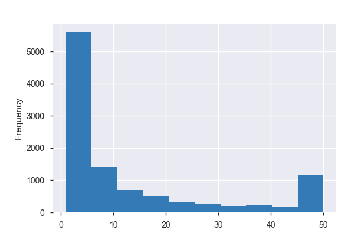

**Common Values**

| Value | Count | Frequency (%) |  |
| --- | --- | --- | --- |
| 1 | 2307 | 22.0% |  |
| 2 | 1300 | 12.4% |  |
| 50 | 1019 | 9.7% |  |
| 3 | 896 | 8.5% |  |
| 4 | 593 | 5.6% |  |
| 5 | 489 | 4.7% |  |
| 6 | 398 | 3.8% |  |
| 7 | 326 | 3.1% |  |
| 8 | 244 | 2.3% |  |
| 9 | 237 | 2.3% |  |
| Other values (40) | 2697 | 25.7% |  |

**Extreme Values**

Minimum 5 values

| Value | Count | Frequency (%) |  |
| --- | --- | --- | --- |
| 1 | 2307 | 22.0% |  |
| 2 | 1300 | 12.4% |  |
| 3 | 896 | 8.5% |  |
| 4 | 593 | 5.6% |  |
| 5 | 489 | 4.7% |  |

Maximum 5 values

| Value | Count | Frequency (%) |  |
| --- | --- | --- | --- |
| 46 | 43 | 0.4% |  |
| 47 | 37 | 0.4% |  |
| 48 | 36 | 0.3% |  |
| 49 | 35 | 0.3% |  |
| 50 | 1019 | 9.7% |  |

Species  
Categorical

| Distinct count | 7 |
| --- | --- |
| Unique (%) | 0.1% |
| Missing (%) | 0.0% |
| Missing (n) | 0 |

| CULEX PIPIENS/RESTUANS | 4752 |
| --- | --- |
| CULEX RESTUANS | 2740 |
| CULEX PIPIENS | 2699 |
| Other values (4) | 315 |

Toggle details

| Value | Count | Frequency (%) |  |
| --- | --- | --- | --- |
| CULEX PIPIENS/RESTUANS | 4752 | 45.2% |  |
| CULEX RESTUANS | 2740 | 26.1% |  |
| CULEX PIPIENS | 2699 | 25.7% |  |
| CULEX TERRITANS | 222 | 2.1% |  |
| CULEX SALINARIUS | 86 | 0.8% |  |
| CULEX TARSALIS | 6 | 0.1% |  |
| CULEX ERRATICUS | 1 | 0.0% |  |

Street  
Categorical

| Distinct count | 128 |
| --- | --- |
| Unique (%) | 1.2% |
| Missing (%) | 0.0% |
| Missing (n) | 0 |

| W OHARE AIRPORT | 750 |
| --- | --- |
| S DOTY AVE | 542 |
| S STONY ISLAND AVE | 347 |
| Other values (125) | 8867 |

Toggle details

| Value | Count | Frequency (%) |  |
| --- | --- | --- | --- |
| W OHARE AIRPORT | 750 | 7.1% |  |
| S DOTY AVE | 542 | 5.2% |  |
| S STONY ISLAND AVE | 347 | 3.3% |  |
| S ASHLAND AVE | 266 | 2.5% |  |
| N OAK PARK AVE | 216 | 2.1% |  |
| W 51ST ST | 185 | 1.8% |  |
| W 127TH PL | 183 | 1.7% |  |
| N PULASKI RD | 173 | 1.6% |  |
| N CANNON DR | 172 | 1.6% |  |
| E 105TH ST | 160 | 1.5% |  |
| Other values (118) | 7512 | 71.5% |  |

Trap  
Categorical

| Distinct count | 136 |
| --- | --- |
| Unique (%) | 1.3% |
| Missing (%) | 0.0% |
| Missing (n) | 0 |

| T900 | 750 |
| --- | --- |
| T115 | 542 |
| T138 | 314 |
| Other values (133) | 8900 |

Toggle details

| Value | Count | Frequency (%) |  |
| --- | --- | --- | --- |
| T900 | 750 | 7.1% |  |
| T115 | 542 | 5.2% |  |
| T138 | 314 | 3.0% |  |
| T002 | 185 | 1.8% |  |
| T135 | 183 | 1.7% |  |
| T054 | 163 | 1.6% |  |
| T128 | 160 | 1.5% |  |
| T151 | 156 | 1.5% |  |
| T212 | 152 | 1.4% |  |
| T090 | 151 | 1.4% |  |
| Other values (126) | 7750 | 73.8% |  |

WnvPresent  
Numeric

| Distinct count | 2 |
| --- | --- |
| Unique (%) | 0.0% |
| Missing (%) | 0.0% |
| Missing (n) | 0 |
| Infinite (%) | 0.0% |
| Infinite (n) | 0 |

| Mean | 0.052446 |
| --- | --- |
| Minimum | 0 |
| Maximum | 1 |
| Zeros (%) | 94.8% |

Toggle details

**Statistics**

Quantile statistics

| Minimum | 0 |
| --- | --- |
| 5-th percentile | 0 |
| Q1 | 0 |
| Median | 0 |
| Q3 | 0 |
| 95-th percentile | 1 |
| Maximum | 1 |
| Range | 1 |
| Interquartile range | 0 |

Descriptive statistics

| Standard deviation | 0.22294 |
| --- | --- |
| Coef of variation | 4.2507 |
| Kurtosis | 14.13 |
| Mean | 0.052446 |
| MAD | 0.099391 |
| Skewness | 4.0159 |
| Sum | 551 |
| Variance | 0.0497 |
| Memory size | 82.1 KiB |

**Histogram**

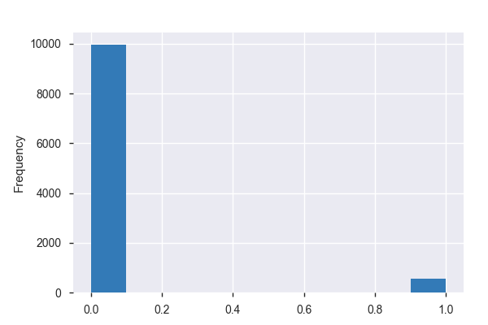

**Common Values**

| Value | Count | Frequency (%) |  |
| --- | --- | --- | --- |
| 0 | 9955 | 94.8% |  |
| 1 | 551 | 5.2% |  |

**Extreme Values**

Minimum 5 values

| Value | Count | Frequency (%) |  |
| --- | --- | --- | --- |
| 0 | 9955 | 94.8% |  |
| 1 | 551 | 5.2% |  |

Maximum 5 values

| Value | Count | Frequency (%) |  |
| --- | --- | --- | --- |
| 0 | 9955 | 94.8% |  |
| 1 | 551 | 5.2% |  |

Sample

|  | Date | Address | Species | Block | Street | Trap | AddressNumberAndStreet | Latitude | Longitude | AddressAccuracy | NumMosquitos | WnvPresent |
| --- | --- | --- | --- | --- | --- | --- | --- | --- | --- | --- | --- | --- |
| 0 | 2007-05-29 | 4100 North Oak Park Avenue, Chicago, IL 60634,... | CULEX PIPIENS/RESTUANS | 41 | N OAK PARK AVE | T002 | 4100 N OAK PARK AVE, Chicago, IL | 41.954690 | -87.800991 | 9 | 1 | 0 |
| 1 | 2007-05-29 | 4100 North Oak Park Avenue, Chicago, IL 60634,... | CULEX RESTUANS | 41 | N OAK PARK AVE | T002 | 4100 N OAK PARK AVE, Chicago, IL | 41.954690 | -87.800991 | 9 | 1 | 0 |
| 2 | 2007-05-29 | 6200 North Mandell Avenue, Chicago, IL 60646, USA | CULEX RESTUANS | 62 | N MANDELL AVE | T007 | 6200 N MANDELL AVE, Chicago, IL | 41.994991 | -87.769279 | 9 | 1 | 0 |
| 3 | 2007-05-29 | 7900 West Foster Avenue, Chicago, IL 60656, USA | CULEX PIPIENS/RESTUANS | 79 | W FOSTER AVE | T015 | 7900 W FOSTER AVE, Chicago, IL | 41.974089 | -87.824812 | 8 | 1 | 0 |
| 4 | 2007-05-29 | 7900 West Foster Avenue, Chicago, IL 60656, USA | CULEX RESTUANS | 79 | W FOSTER AVE | T015 | 7900 W FOSTER AVE, Chicago, IL | 41.974089 | -87.824812 | 8 | 4 | 0 |

```python
pdp.ProfileReport(traps)
```

From this profile report of traps, there are a few things we found important and will deal with:

- the multiple address features seem irrelevant with Latitude and Longitude. Remove them
- WnvPresent has nearly 95% zero!!! We will need to stratify our training data so that the negative class doesn't dominate the results
- Species has 7 categorical values: create dummies
- Date feature should be converted to date datatype
- 813 duplicate rows: We know from the data descriptions that observations are capped at 50 mosquitos, so it's definitely possible that a single observation spans a couple of records. We'll leave the duplicates for this reason, and sum up the number of mosquitos with a groupby.

```python
## We can tackle the multiple addresses and the grouping in this one step
traps = traps[['Trap',
               'Latitude',
               'Longitude',
               'Date',
               'Species',
               'WnvPresent',
               'NumMosquitos']].groupby(['Trap',
                                         'Latitude',
                                         'Longitude',
                                         'Date',
                                         'Species',
                                         'WnvPresent']).agg({'NumMosquitos':np.sum}).reset_index()

feats = traps.columns

## get species dummies and add to traps df
traps = pd.get_dummies(traps, columns=['Species'])

## convert to date
traps.Date = pd.to_datetime(traps.Date)
```

Let's look at the features that we'll have when we run our test data through the models:

```python
test.columns
```

```
Index([u'Id', u'Date', u'Address', u'Species', u'Block', u'Street', u'Trap',
       u'AddressNumberAndStreet', u'Latitude', u'Longitude',
       u'AddressAccuracy'],
      dtype='object')
```

```python
# The test data doesn't include NumMosquitos...
# this means we should drop this column from traps
# and then drop the duplicates

traps.drop('NumMosquitos',axis=1,inplace=True)
traps.drop_duplicates(inplace=True)


## Might as well go ahead and perform the same modifications on the test data

# remove the redundant address features from test
test = test[feats.drop(['WnvPresent','NumMosquitos'])]

## get species dummies and add to traps df
test = pd.get_dummies(test, columns=['Species'])

## convert to date
test.Date = pd.to_datetime(test.Date)
```

## Spray

Overview

Dataset info

| Number of variables | 4 |
| --- | --- |
| Number of observations | 14835 |
| Total Missing (%) | 1.0% |
| Total size in memory | 463.7 KiB |
| Average record size in memory | 32.0 B |

Variables types

| Numeric | 2 |
| --- | --- |
| Categorical | 2 |
| Date | 0 |
| Text (Unique) | 0 |
| Rejected | 0 |

Warnings

- `Time` has 584 / 3.9% missing values Missing

- `Time` has a high cardinality: 8584 distinct values Warning

- Dataset has 541 duplicate rows Warning

Variables

Date  
Categorical

| Distinct count | 10 |
| --- | --- |
| Unique (%) | 0.1% |
| Missing (%) | 0.0% |
| Missing (n) | 0 |

| 2013-08-15 | 2668 |
| --- | --- |
| 2013-08-29 | 2302 |
| 2013-07-17 | 2202 |
| Other values (7) | 7663 |

Toggle details

| Value | Count | Frequency (%) |  |
| --- | --- | --- | --- |
| 2013-08-15 | 2668 | 18.0% |  |
| 2013-08-29 | 2302 | 15.5% |  |
| 2013-07-17 | 2202 | 14.8% |  |
| 2011-09-07 | 2114 | 14.3% |  |
| 2013-07-25 | 1607 | 10.8% |  |
| 2013-08-22 | 1587 | 10.7% |  |
| 2013-08-08 | 1195 | 8.1% |  |
| 2013-09-05 | 924 | 6.2% |  |
| 2013-08-16 | 141 | 1.0% |  |
| 2011-08-29 | 95 | 0.6% |  |

Latitude  
Numeric

| Distinct count | 12887 |
| --- | --- |
| Unique (%) | 86.9% |
| Missing (%) | 0.0% |
| Missing (n) | 0 |
| Infinite (%) | 0.0% |
| Infinite (n) | 0 |

| Mean | 41.905 |
| --- | --- |
| Minimum | 41.714 |
| Maximum | 42.396 |
| Zeros (%) | 0.0% |

Toggle details

**Statistics**

Quantile statistics

| Minimum | 41.714 |
| --- | --- |
| 5-th percentile | 41.725 |
| Q1 | 41.785 |
| Median | 41.94 |
| Q3 | 41.981 |
| 95-th percentile | 42.006 |
| Maximum | 42.396 |
| Range | 0.68206 |
| Interquartile range | 0.19598 |

Descriptive statistics

| Standard deviation | 0.10438 |
| --- | --- |
| Coef of variation | 0.0024909 |
| Kurtosis | 1.7358 |
| Mean | 41.905 |
| MAD | 0.083218 |
| Skewness | -0.08886 |
| Sum | 621660 |
| Variance | 0.010895 |
| Memory size | 116.0 KiB |

**Histogram**

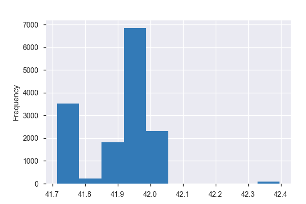

**Common Values**

| Value | Count | Frequency (%) |  |
| --- | --- | --- | --- |
| 41.98646 | 541 | 3.6% |  |
| 41.9953963549 | 11 | 0.1% |  |
| 41.9827717583 | 10 | 0.1% |  |
| 41.9944843118 | 9 | 0.1% |  |
| 41.9856518944 | 9 | 0.1% |  |
| 41.9848838581 | 8 | 0.1% |  |
| 41.9935242665 | 8 | 0.1% |  |
| 41.9969324275 | 8 | 0.1% |  |
| 41.9840678196 | 8 | 0.1% |  |
| 41.9950123368 | 7 | 0.0% |  |
| Other values (12877) | 14216 | 95.8% |  |

**Extreme Values**

Minimum 5 values

| Value | Count | Frequency (%) |  |
| --- | --- | --- | --- |
| 41.713925 | 1 | 0.0% |  |
| 41.714005 | 1 | 0.0% |  |
| 41.7140416667 | 1 | 0.0% |  |
| 41.7140983333 | 1 | 0.0% |  |
| 41.7141116667 | 1 | 0.0% |  |

Maximum 5 values

| Value | Count | Frequency (%) |  |
| --- | --- | --- | --- |
| 42.395095 | 1 | 0.0% |  |
| 42.3952183333 | 1 | 0.0% |  |
| 42.3953516667 | 1 | 0.0% |  |
| 42.3956966667 | 1 | 0.0% |  |
| 42.3959833333 | 1 | 0.0% |  |

Longitude  
Numeric

| Distinct count | 13007 |
| --- | --- |
| Unique (%) | 87.7% |
| Missing (%) | 0.0% |
| Missing (n) | 0 |
| Infinite (%) | 0.0% |
| Infinite (n) | 0 |

| Mean | -87.737 |
| --- | --- |
| Minimum | -88.096 |
| Maximum | -87.587 |
| Zeros (%) | 0.0% |

Toggle details

**Statistics**

Quantile statistics

| Minimum | -88.096 |
| --- | --- |
| 5-th percentile | -87.818 |
| Q1 | -87.794 |
| Median | -87.728 |
| Q3 | -87.694 |
| 95-th percentile | -87.627 |
| Maximum | -87.587 |
| Range | 0.50974 |
| Interquartile range | 0.10012 |

Descriptive statistics

| Standard deviation | 0.067292 |
| --- | --- |
| Coef of variation | -0.00076698 |
| Kurtosis | 3.5397 |
| Mean | -87.737 |
| MAD | 0.054238 |
| Skewness | -0.65318 |
| Sum | -1301600 |
| Variance | 0.0045282 |
| Memory size | 116.0 KiB |

**Histogram**

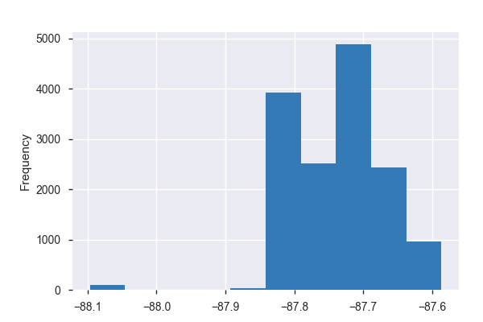

**Common Values**

| Value | Count | Frequency (%) |  |
| --- | --- | --- | --- |
| -87.794225 | 541 | 3.6% |  |
| -87.8069107897 | 9 | 0.1% |  |
| -87.8068627874 | 9 | 0.1% |  |
| -87.8167512547 | 7 | 0.0% |  |
| -87.805710733 | 6 | 0.0% |  |
| -87.8056147285 | 6 | 0.0% |  |
| -87.8104149553 | 5 | 0.0% |  |
| -87.8083508578 | 5 | 0.0% |  |
| -87.8115670097 | 5 | 0.0% |  |
| -87.8137271118 | 5 | 0.0% |  |
| Other values (12997) | 14237 | 96.0% |  |

**Extreme Values**

Minimum 5 values

| Value | Count | Frequency (%) |  |
| --- | --- | --- | --- |
| -88.0964683333 | 1 | 0.0% |  |
| -88.0964466667 | 1 | 0.0% |  |
| -88.096445 | 1 | 0.0% |  |
| -88.0964433333 | 1 | 0.0% |  |
| -88.09644 | 1 | 0.0% |  |

Maximum 5 values

| Value | Count | Frequency (%) |  |
| --- | --- | --- | --- |
| -87.5867916667 | 1 | 0.0% |  |
| -87.5867866667 | 1 | 0.0% |  |
| -87.586775 | 1 | 0.0% |  |
| -87.586755 | 1 | 0.0% |  |
| -87.5867266667 | 1 | 0.0% |  |

Time  
Categorical

| Distinct count | 8584 |
| --- | --- |
| Unique (%) | 60.2% |
| Missing (%) | 3.9% |
| Missing (n) | 584 |

| 7:44:32 PM | 541 |
| --- | --- |
| 8:59:06 PM | 5 |
| 8:55:36 PM | 5 |
| Other values (8580) | 13700 |
| (Missing) | 584 |

Toggle details

| Value | Count | Frequency (%) |  |
| --- | --- | --- | --- |
| 7:44:32 PM | 541 | 3.6% |  |
| 8:59:06 PM | 5 | 0.0% |  |
| 8:55:36 PM | 5 | 0.0% |  |
| 8:57:56 PM | 5 | 0.0% |  |
| 9:35:47 PM | 5 | 0.0% |  |
| 9:37:27 PM | 5 | 0.0% |  |
| 8:57:46 PM | 5 | 0.0% |  |
| 8:58:26 PM | 5 | 0.0% |  |
| 9:40:27 PM | 5 | 0.0% |  |
| 9:31:27 PM | 5 | 0.0% |  |
| Other values (8573) | 13665 | 92.1% |  |
| (Missing) | 584 | 3.9% |  |

Sample

|  | Date | Time | Latitude | Longitude |
| --- | --- | --- | --- | --- |
| 0 | 2011-08-29 | 6:56:58 PM | 42.391623 | -88.089163 |
| 1 | 2011-08-29 | 6:57:08 PM | 42.391348 | -88.089163 |
| 2 | 2011-08-29 | 6:57:18 PM | 42.391022 | -88.089157 |
| 3 | 2011-08-29 | 6:57:28 PM | 42.390637 | -88.089158 |
| 4 | 2011-08-29 | 6:57:38 PM | 42.390410 | -88.088858 |

```python
pdp.ProfileReport(spray)
```

This is a really simple dataset. There are missing values in time, but it doesn't seem like a significant feature as it's too specific and variable. We will exclude Time, and don't have any modifications to make aside from converting the Date feature into date type.

```python
spray.Date = pd.to_datetime(spray.Date)
```

```python
spray.duplicated().sum()
```

```
541
```

```python
# Drop the duplicate records
spray.drop_duplicates(inplace=True)
```

## Weather

Overview

Dataset info

| Number of variables | 22 |
| --- | --- |
| Number of observations | 2944 |
| Total Missing (%) | 0.0% |
| Total size in memory | 506.1 KiB |
| Average record size in memory | 176.0 B |

Variables types

| Numeric | 5 |
| --- | --- |
| Categorical | 15 |
| Date | 0 |
| Text (Unique) | 0 |
| Rejected | 2 |

Warnings

- `AvgSpeed` has a high cardinality: 178 distinct values Warning

- `CodeSum` has a high cardinality: 98 distinct values Warning

- `Date` has a high cardinality: 1472 distinct values Warning

- `DewPoint` is highly correlated with `Tmin` (ρ = 0.90436) Rejected

- `PrecipTotal` has a high cardinality: 168 distinct values Warning

- `SeaLevel` has a high cardinality: 102 distinct values Warning

- `StnPressure` has a high cardinality: 104 distinct values Warning

- `Sunrise` has a high cardinality: 122 distinct values Warning

- `Sunset` has a high cardinality: 119 distinct values Warning

- `Tavg` has a high cardinality: 60 distinct values Warning

- `Water1` has constant value M Rejected

Variables

AvgSpeed  
Categorical

| Distinct count | 178 |
| --- | --- |
| Unique (%) | 6.0% |
| Missing (%) | 0.0% |
| Missing (n) | 0 |

| 6.9 | 63 |
| --- | --- |
| 5.8 | 60 |
| 7.4 | 55 |
| Other values (175) | 2766 |

Toggle details

| Value | Count | Frequency (%) |  |
| --- | --- | --- | --- |
| 6.9 | 63 | 2.1% |  |
| 5.8 | 60 | 2.0% |  |
| 7.4 | 55 | 1.9% |  |
| 8.1 | 49 | 1.7% |  |
| 7.0 | 47 | 1.6% |  |
| 7.7 | 44 | 1.5% |  |
| 9.2 | 44 | 1.5% |  |
| 8.0 | 43 | 1.5% |  |
| 6.0 | 42 | 1.4% |  |
| 7.3 | 42 | 1.4% |  |
| Other values (168) | 2455 | 83.4% |  |

CodeSum  
Categorical

| Distinct count | 98 |
| --- | --- |
| Unique (%) | 3.3% |
| Missing (%) | 0.0% |
| Missing (n) | 0 |

|  | 1609 |
| --- | --- |
| RA | 296 |
| RA BR | 238 |
| Other values (95) | 801 |

Toggle details

| Value | Count | Frequency (%) |  |
| --- | --- | --- | --- |
|  | 1609 | 54.7% |  |
| RA | 296 | 10.1% |  |
| RA BR | 238 | 8.1% |  |
| BR | 110 | 3.7% |  |
| TSRA RA BR | 92 | 3.1% |  |
| BR HZ | 81 | 2.8% |  |
| RA DZ BR | 65 | 2.2% |  |
| TSRA RA | 43 | 1.5% |  |
| HZ | 39 | 1.3% |  |
| RA BR HZ | 38 | 1.3% |  |
| Other values (88) | 333 | 11.3% |  |

Cool  
Categorical

| Distinct count | 31 |
| --- | --- |
| Unique (%) | 1.1% |
| Missing (%) | 0.0% |
| Missing (n) | 0 |

| 0 | 1147 |
| --- | --- |
| 8 | 138 |
| 12 | 117 |
| Other values (28) | 1542 |

Toggle details

| Value | Count | Frequency (%) |  |
| --- | --- | --- | --- |
| 0 | 1147 | 39.0% |  |
| 8 | 138 | 4.7% |  |
| 12 | 117 | 4.0% |  |
| 5 | 117 | 4.0% |  |
| 10 | 110 | 3.7% |  |
| 6 | 109 | 3.7% |  |
| 9 | 107 | 3.6% |  |
| 7 | 104 | 3.5% |  |
| 4 | 103 | 3.5% |  |
| 13 | 102 | 3.5% |  |
| Other values (21) | 790 | 26.8% |  |

Date  
Categorical

| Distinct count | 1472 |
| --- | --- |
| Unique (%) | 50.0% |
| Missing (%) | 0.0% |
| Missing (n) | 0 |

| 2013-06-02 | 2 |
| --- | --- |
| 2009-09-14 | 2 |
| 2014-05-31 | 2 |
| Other values (1469) | 2938 |

Toggle details

| Value | Count | Frequency (%) |  |
| --- | --- | --- | --- |
| 2013-06-02 | 2 | 0.1% |  |
| 2009-09-14 | 2 | 0.1% |  |
| 2014-05-31 | 2 | 0.1% |  |
| 2014-09-26 | 2 | 0.1% |  |
| 2009-09-13 | 2 | 0.1% |  |
| 2009-09-12 | 2 | 0.1% |  |
| 2009-09-11 | 2 | 0.1% |  |
| 2009-09-10 | 2 | 0.1% |  |
| 2009-09-17 | 2 | 0.1% |  |
| 2009-09-16 | 2 | 0.1% |  |
| Other values (1462) | 2924 | 99.3% |  |

Depart  
Categorical

| Distinct count | 42 |
| --- | --- |
| Unique (%) | 1.4% |
| Missing (%) | 0.0% |
| Missing (n) | 0 |

| M | 1472 |
| --- | --- |
| 2 | 93 |
| -1 | 84 |
| Other values (39) | 1295 |

Toggle details

| Value | Count | Frequency (%) |  |
| --- | --- | --- | --- |
| M | 1472 | 50.0% |  |
| 2 | 93 | 3.2% |  |
| -1 | 84 | 2.9% |  |
| -2 | 80 | 2.7% |  |
| 5 | 77 | 2.6% |  |
| 7 | 76 | 2.6% |  |
| 1 | 76 | 2.6% |  |
| 3 | 75 | 2.5% |  |
| 0 | 74 | 2.5% |  |
| -3 | 72 | 2.4% |  |
| Other values (32) | 765 | 26.0% |  |

Depth  
Categorical

| Distinct count | 2 |
| --- | --- |
| Unique (%) | 0.1% |
| Missing (%) | 0.0% |
| Missing (n) | 0 |

| M | 1472 |
| --- | --- |
| 0 | 1472 |

Toggle details

| Value | Count | Frequency (%) |  |
| --- | --- | --- | --- |
| M | 1472 | 50.0% |  |
| 0 | 1472 | 50.0% |  |

`DewPoint`  
Highly correlated

*This variable is highly correlated with `Tmin` and should be ignored for analysis*

| Correlation | 0.90436 |
| --- | --- |

Heat  
Categorical

| Distinct count | 31 |
| --- | --- |
| Unique (%) | 1.1% |
| Missing (%) | 0.0% |
| Missing (n) | 0 |

| 0 | 1870 |
| --- | --- |
| 4 | 88 |
| 1 | 86 |
| Other values (28) | 900 |

Toggle details

| Value | Count | Frequency (%) |  |
| --- | --- | --- | --- |
| 0 | 1870 | 63.5% |  |
| 4 | 88 | 3.0% |  |
| 1 | 86 | 2.9% |  |
| 2 | 81 | 2.8% |  |
| 8 | 67 | 2.3% |  |
| 3 | 66 | 2.2% |  |
| 5 | 61 | 2.1% |  |
| 15 | 57 | 1.9% |  |
| 7 | 49 | 1.7% |  |
| 12 | 49 | 1.7% |  |
| Other values (21) | 470 | 16.0% |  |

PrecipTotal  
Categorical

| Distinct count | 168 |
| --- | --- |
| Unique (%) | 5.7% |
| Missing (%) | 0.0% |
| Missing (n) | 0 |

| 0.00 | 1577 |
| --- | --- |
| T | 318 |
| 0.01 | 127 |
| Other values (165) | 922 |

Toggle details

| Value | Count | Frequency (%) |  |
| --- | --- | --- | --- |
| 0.00 | 1577 | 53.6% |  |
| T | 318 | 10.8% |  |
| 0.01 | 127 | 4.3% |  |
| 0.02 | 63 | 2.1% |  |
| 0.03 | 46 | 1.6% |  |
| 0.04 | 36 | 1.2% |  |
| 0.05 | 32 | 1.1% |  |
| 0.08 | 28 | 1.0% |  |
| 0.12 | 28 | 1.0% |  |
| 0.06 | 27 | 0.9% |  |
| Other values (158) | 662 | 22.5% |  |

ResultDir  
Numeric

| Distinct count | 36 |
| --- | --- |
| Unique (%) | 1.2% |
| Missing (%) | 0.0% |
| Missing (n) | 0 |
| Infinite (%) | 0.0% |
| Infinite (n) | 0 |

| Mean | 17.495 |
| --- | --- |
| Minimum | 1 |
| Maximum | 36 |
| Zeros (%) | 0.0% |

Toggle details

**Statistics**

Quantile statistics

| Minimum | 1 |
| --- | --- |
| 5-th percentile | 2 |
| Q1 | 7 |
| Median | 19 |
| Q3 | 25 |
| 95-th percentile | 34 |
| Maximum | 36 |
| Range | 35 |
| Interquartile range | 18 |

Descriptive statistics

| Standard deviation | 10.064 |
| --- | --- |
| Coef of variation | 0.57523 |
| Kurtosis | -1.1616 |
| Mean | 17.495 |
| MAD | 8.7028 |
| Skewness | -0.062597 |
| Sum | 51505 |
| Variance | 101.28 |
| Memory size | 23.1 KiB |

**Histogram**

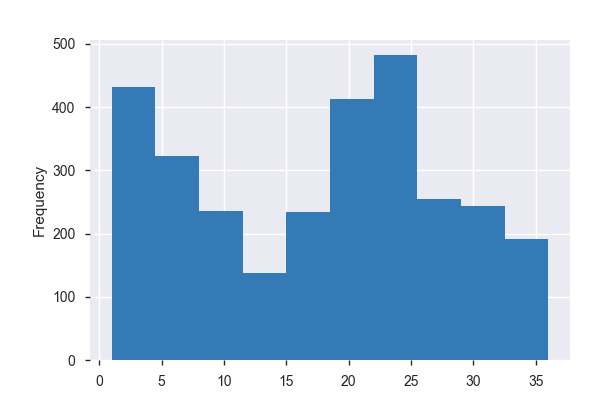

**Common Values**

| Value | Count | Frequency (%) |  |
| --- | --- | --- | --- |
| 21 | 156 | 5.3% |  |
| 3 | 139 | 4.7% |  |
| 23 | 138 | 4.7% |  |
| 19 | 138 | 4.7% |  |
| 24 | 122 | 4.1% |  |
| 4 | 121 | 4.1% |  |
| 20 | 118 | 4.0% |  |
| 22 | 116 | 3.9% |  |
| 5 | 113 | 3.8% |  |
| 6 | 111 | 3.8% |  |
| Other values (26) | 1672 | 56.8% |  |

**Extreme Values**

Minimum 5 values

| Value | Count | Frequency (%) |  |
| --- | --- | --- | --- |
| 1 | 62 | 2.1% |  |
| 2 | 110 | 3.7% |  |
| 3 | 139 | 4.7% |  |
| 4 | 121 | 4.1% |  |
| 5 | 113 | 3.8% |  |

Maximum 5 values

| Value | Count | Frequency (%) |  |
| --- | --- | --- | --- |
| 32 | 47 | 1.6% |  |
| 33 | 34 | 1.2% |  |
| 34 | 49 | 1.7% |  |
| 35 | 37 | 1.3% |  |
| 36 | 72 | 2.4% |  |

ResultSpeed  
Numeric

| Distinct count | 190 |
| --- | --- |
| Unique (%) | 6.5% |
| Missing (%) | 0.0% |
| Missing (n) | 0 |
| Infinite (%) | 0.0% |
| Infinite (n) | 0 |

| Mean | 6.9607 |
| --- | --- |
| Minimum | 0.1 |
| Maximum | 24.1 |
| Zeros (%) | 0.0% |

Toggle details

**Statistics**

Quantile statistics

| Minimum | 0.1 |
| --- | --- |
| 5-th percentile | 1.9 |
| Q1 | 4.3 |
| Median | 6.4 |
| Q3 | 9.2 |
| 95-th percentile | 13.5 |
| Maximum | 24.1 |
| Range | 24 |
| Interquartile range | 4.9 |

Descriptive statistics

| Standard deviation | 3.5875 |
| --- | --- |
| Coef of variation | 0.5154 |
| Kurtosis | 0.7425 |
| Mean | 6.9607 |
| MAD | 2.8541 |
| Skewness | 0.73492 |
| Sum | 20492 |
| Variance | 12.87 |
| Memory size | 23.1 KiB |

**Histogram**

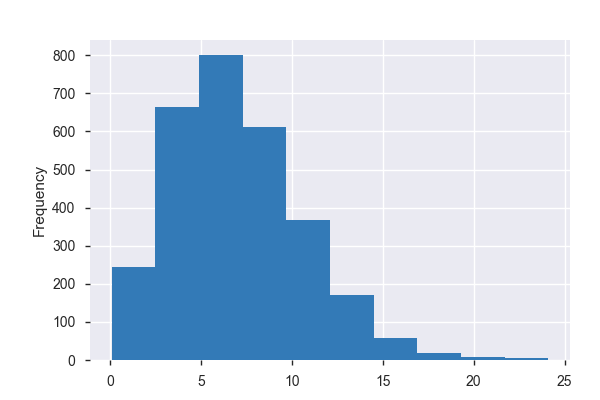

**Common Values**

| Value | Count | Frequency (%) |  |
| --- | --- | --- | --- |
| 5.9 | 49 | 1.7% |  |
| 6.4 | 47 | 1.6% |  |
| 6.2 | 42 | 1.4% |  |
| 5.3 | 42 | 1.4% |  |
| 4.9 | 38 | 1.3% |  |
| 4.8 | 37 | 1.3% |  |
| 6.0 | 37 | 1.3% |  |
| 5.8 | 37 | 1.3% |  |
| 6.3 | 37 | 1.3% |  |
| 8.3 | 36 | 1.2% |  |
| Other values (180) | 2542 | 86.3% |  |

**Extreme Values**

Minimum 5 values

| Value | Count | Frequency (%) |  |
| --- | --- | --- | --- |
| 0.1 | 1 | 0.0% |  |
| 0.2 | 1 | 0.0% |  |
| 0.3 | 3 | 0.1% |  |
| 0.4 | 3 | 0.1% |  |
| 0.5 | 3 | 0.1% |  |

Maximum 5 values

| Value | Count | Frequency (%) |  |
| --- | --- | --- | --- |
| 21.7 | 1 | 0.0% |  |
| 21.8 | 1 | 0.0% |  |
| 22.6 | 1 | 0.0% |  |
| 22.7 | 1 | 0.0% |  |
| 24.1 | 1 | 0.0% |  |

SeaLevel  
Categorical

| Distinct count | 102 |
| --- | --- |
| Unique (%) | 3.5% |
| Missing (%) | 0.0% |
| Missing (n) | 0 |

| 30.00 | 96 |
| --- | --- |
| 29.94 | 85 |
| 29.98 | 85 |
| Other values (99) | 2678 |

Toggle details

| Value | Count | Frequency (%) |  |
| --- | --- | --- | --- |
| 30.00 | 96 | 3.3% |  |
| 29.94 | 85 | 2.9% |  |
| 29.98 | 85 | 2.9% |  |
| 29.92 | 83 | 2.8% |  |
| 29.89 | 82 | 2.8% |  |
| 30.05 | 81 | 2.8% |  |
| 29.95 | 80 | 2.7% |  |
| 29.91 | 80 | 2.7% |  |
| 30.02 | 80 | 2.7% |  |
| 29.93 | 79 | 2.7% |  |
| Other values (92) | 2113 | 71.8% |  |

SnowFall  
Categorical

| Distinct count | 4 |
| --- | --- |
| Unique (%) | 0.1% |
| Missing (%) | 0.0% |
| Missing (n) | 0 |

| M | 1472 |
| --- | --- |
| 0.0 | 1459 |
| T | 12 |

Toggle details

| Value | Count | Frequency (%) |  |
| --- | --- | --- | --- |
| M | 1472 | 50.0% |  |
| 0.0 | 1459 | 49.6% |  |
| T | 12 | 0.4% |  |
| 0.1 | 1 | 0.0% |  |

Station  
Numeric

| Distinct count | 2 |
| --- | --- |
| Unique (%) | 0.1% |
| Missing (%) | 0.0% |
| Missing (n) | 0 |
| Infinite (%) | 0.0% |
| Infinite (n) | 0 |

| Mean | 1.5 |
| --- | --- |
| Minimum | 1 |
| Maximum | 2 |
| Zeros (%) | 0.0% |

Toggle details

**Statistics**

Quantile statistics

| Minimum | 1 |
| --- | --- |
| 5-th percentile | 1 |
| Q1 | 1 |
| Median | 1.5 |
| Q3 | 2 |
| 95-th percentile | 2 |
| Maximum | 2 |
| Range | 1 |
| Interquartile range | 1 |

Descriptive statistics

| Standard deviation | 0.50008 |
| --- | --- |
| Coef of variation | 0.33339 |
| Kurtosis | -2.0014 |
| Mean | 1.5 |
| MAD | 0.5 |
| Skewness | 0 |
| Sum | 4416 |
| Variance | 0.25008 |
| Memory size | 23.1 KiB |

**Histogram**

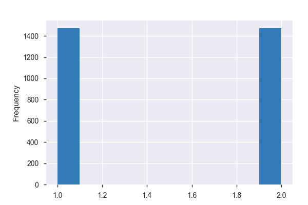

**Common Values**

| Value | Count | Frequency (%) |  |
| --- | --- | --- | --- |
| 1 | 1472 | 50.0% |  |
| 2 | 1472 | 50.0% |  |

**Extreme Values**

Minimum 5 values

| Value | Count | Frequency (%) |  |
| --- | --- | --- | --- |
| 1 | 1472 | 50.0% |  |
| 2 | 1472 | 50.0% |  |

Maximum 5 values

| Value | Count | Frequency (%) |  |
| --- | --- | --- | --- |
| 1 | 1472 | 50.0% |  |
| 2 | 1472 | 50.0% |  |

StnPressure  
Categorical

| Distinct count | 104 |
| --- | --- |
| Unique (%) | 3.5% |
| Missing (%) | 0.0% |
| Missing (n) | 0 |

| 29.34 | 128 |
| --- | --- |
| 29.28 | 124 |
| 29.26 | 123 |
| Other values (101) | 2569 |

Toggle details

| Value | Count | Frequency (%) |  |
| --- | --- | --- | --- |
| 29.34 | 128 | 4.3% |  |
| 29.28 | 124 | 4.2% |  |
| 29.26 | 123 | 4.2% |  |
| 29.21 | 107 | 3.6% |  |
| 29.31 | 106 | 3.6% |  |
| 29.23 | 104 | 3.5% |  |
| 29.36 | 96 | 3.3% |  |
| 29.41 | 91 | 3.1% |  |
| 29.39 | 89 | 3.0% |  |
| 29.29 | 86 | 2.9% |  |
| Other values (94) | 1890 | 64.2% |  |

Sunrise  
Categorical

| Distinct count | 122 |
| --- | --- |
| Unique (%) | 4.1% |
| Missing (%) | 0.0% |
| Missing (n) | 0 |

| - | 1472 |
| --- | --- |
| 0416 | 104 |
| 0417 | 64 |
| Other values (119) | 1304 |

Toggle details

| Value | Count | Frequency (%) |  |
| --- | --- | --- | --- |
| - | 1472 | 50.0% |  |
| 0416 | 104 | 3.5% |  |
| 0417 | 64 | 2.2% |  |
| 0419 | 40 | 1.4% |  |
| 0418 | 32 | 1.1% |  |
| 0420 | 32 | 1.1% |  |
| 0422 | 32 | 1.1% |  |
| 0425 | 32 | 1.1% |  |
| 0421 | 24 | 0.8% |  |
| 0423 | 24 | 0.8% |  |
| Other values (112) | 1088 | 37.0% |  |

Sunset  
Categorical

| Distinct count | 119 |
| --- | --- |
| Unique (%) | 4.0% |
| Missing (%) | 0.0% |
| Missing (n) | 0 |

| - | 1472 |
| --- | --- |
| 1931 | 96 |
| 1930 | 56 |
| Other values (116) | 1320 |

Toggle details

| Value | Count | Frequency (%) |  |
| --- | --- | --- | --- |
| - | 1472 | 50.0% |  |
| 1931 | 96 | 3.3% |  |
| 1930 | 56 | 1.9% |  |
| 1929 | 48 | 1.6% |  |
| 1923 | 32 | 1.1% |  |
| 1925 | 32 | 1.1% |  |
| 1927 | 32 | 1.1% |  |
| 1928 | 32 | 1.1% |  |
| 1926 | 24 | 0.8% |  |
| 1918 | 24 | 0.8% |  |
| Other values (109) | 1096 | 37.2% |  |

Tavg  
Categorical

| Distinct count | 60 |
| --- | --- |
| Unique (%) | 2.0% |
| Missing (%) | 0.0% |
| Missing (n) | 0 |

| 73 | 138 |
| --- | --- |
| 77 | 117 |
| 70 | 117 |
| Other values (57) | 2572 |

Toggle details

| Value | Count | Frequency (%) |  |
| --- | --- | --- | --- |
| 73 | 138 | 4.7% |  |
| 77 | 117 | 4.0% |  |
| 70 | 117 | 4.0% |  |
| 75 | 110 | 3.7% |  |
| 71 | 109 | 3.7% |  |
| 74 | 107 | 3.6% |  |
| 72 | 104 | 3.5% |  |
| 69 | 103 | 3.5% |  |
| 78 | 102 | 3.5% |  |
| 76 | 100 | 3.4% |  |
| Other values (50) | 1837 | 62.4% |  |

Tmax  
Numeric

| Distinct count | 63 |
| --- | --- |
| Unique (%) | 2.1% |
| Missing (%) | 0.0% |
| Missing (n) | 0 |
| Infinite (%) | 0.0% |
| Infinite (n) | 0 |

| Mean | 76.166 |
| --- | --- |
| Minimum | 41 |
| Maximum | 104 |
| Zeros (%) | 0.0% |

Toggle details

**Statistics**

Quantile statistics

| Minimum | 41 |
| --- | --- |
| 5-th percentile | 54 |
| Q1 | 69 |
| Median | 78 |
| Q3 | 85 |
| 95-th percentile | 92 |
| Maximum | 104 |
| Range | 63 |
| Interquartile range | 16 |

Descriptive statistics

| Standard deviation | 11.462 |
| --- | --- |
| Coef of variation | 0.15049 |
| Kurtosis | -0.26791 |
| Mean | 76.166 |
| MAD | 9.3499 |
| Skewness | -0.55888 |
| Sum | 224233 |
| Variance | 131.38 |
| Memory size | 23.1 KiB |

**Histogram**

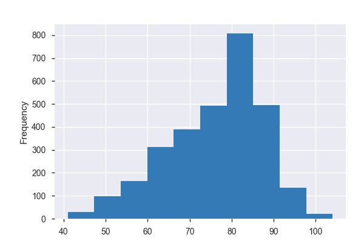

**Common Values**

| Value | Count | Frequency (%) |  |
| --- | --- | --- | --- |
| 84 | 128 | 4.3% |  |
| 79 | 121 | 4.1% |  |
| 82 | 118 | 4.0% |  |
| 81 | 117 | 4.0% |  |
| 83 | 109 | 3.7% |  |
| 80 | 107 | 3.6% |  |
| 85 | 107 | 3.6% |  |
| 86 | 101 | 3.4% |  |
| 77 | 100 | 3.4% |  |
| 87 | 97 | 3.3% |  |
| Other values (53) | 1839 | 62.5% |  |

**Extreme Values**

Minimum 5 values

| Value | Count | Frequency (%) |  |
| --- | --- | --- | --- |
| 41 | 1 | 0.0% |  |
| 42 | 1 | 0.0% |  |
| 44 | 5 | 0.2% |  |
| 45 | 5 | 0.2% |  |
| 46 | 9 | 0.3% |  |

Maximum 5 values

| Value | Count | Frequency (%) |  |
| --- | --- | --- | --- |
| 100 | 3 | 0.1% |  |
| 101 | 4 | 0.1% |  |
| 102 | 2 | 0.1% |  |
| 103 | 2 | 0.1% |  |
| 104 | 1 | 0.0% |  |

Tmin  
Numeric

| Distinct count | 54 |
| --- | --- |
| Unique (%) | 1.8% |
| Missing (%) | 0.0% |
| Missing (n) | 0 |
| Infinite (%) | 0.0% |
| Infinite (n) | 0 |

| Mean | 57.81 |
| --- | --- |
| Minimum | 29 |
| Maximum | 83 |
| Zeros (%) | 0.0% |

Toggle details

**Statistics**

Quantile statistics

| Minimum | 29 |
| --- | --- |
| 5-th percentile | 40 |
| Q1 | 50 |
| Median | 59 |
| Q3 | 66 |
| 95-th percentile | 73 |
| Maximum | 83 |
| Range | 54 |
| Interquartile range | 16 |

Descriptive statistics

| Standard deviation | 10.382 |
| --- | --- |
| Coef of variation | 0.17959 |
| Kurtosis | -0.577 |
| Mean | 57.81 |
| MAD | 8.6016 |
| Skewness | -0.3523 |
| Sum | 170194 |
| Variance | 107.78 |
| Memory size | 23.1 KiB |

**Histogram**

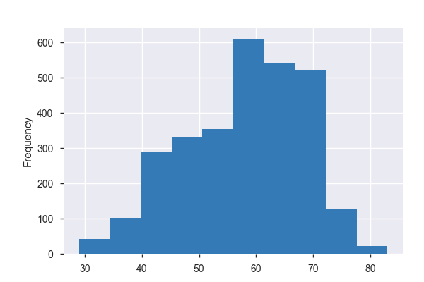

**Common Values**

| Value | Count | Frequency (%) |  |
| --- | --- | --- | --- |
| 63 | 121 | 4.1% |  |
| 65 | 111 | 3.8% |  |
| 60 | 109 | 3.7% |  |
| 61 | 106 | 3.6% |  |
| 62 | 105 | 3.6% |  |
| 66 | 103 | 3.5% |  |
| 68 | 103 | 3.5% |  |
| 57 | 103 | 3.5% |  |
| 64 | 101 | 3.4% |  |
| 59 | 100 | 3.4% |  |
| Other values (44) | 1882 | 63.9% |  |

**Extreme Values**

Minimum 5 values

| Value | Count | Frequency (%) |  |
| --- | --- | --- | --- |
| 29 | 6 | 0.2% |  |
| 31 | 7 | 0.2% |  |
| 32 | 7 | 0.2% |  |
| 33 | 10 | 0.3% |  |
| 34 | 12 | 0.4% |  |

Maximum 5 values

| Value | Count | Frequency (%) |  |
| --- | --- | --- | --- |
| 79 | 9 | 0.3% |  |
| 80 | 3 | 0.1% |  |
| 81 | 3 | 0.1% |  |
| 82 | 2 | 0.1% |  |
| 83 | 1 | 0.0% |  |

`Water1`  
Constant

*This variable is constant and should be ignored for analysis*

| Constant value | M |
| --- | --- |

WetBulb  
Categorical

| Distinct count | 48 |
| --- | --- |
| Unique (%) | 1.6% |
| Missing (%) | 0.0% |
| Missing (n) | 0 |

| 63 | 135 |
| --- | --- |
| 65 | 131 |
| 59 | 129 |
| Other values (45) | 2549 |

Toggle details

| Value | Count | Frequency (%) |  |
| --- | --- | --- | --- |
| 63 | 135 | 4.6% |  |
| 65 | 131 | 4.4% |  |
| 59 | 129 | 4.4% |  |
| 61 | 123 | 4.2% |  |
| 64 | 121 | 4.1% |  |
| 62 | 118 | 4.0% |  |
| 67 | 117 | 4.0% |  |
| 66 | 113 | 3.8% |  |
| 60 | 111 | 3.8% |  |
| 69 | 107 | 3.6% |  |
| Other values (38) | 1739 | 59.1% |  |

Sample

|  | Station | Date | Tmax | Tmin | Tavg | Depart | DewPoint | WetBulb | Heat | Cool | Sunrise | Sunset | CodeSum | Depth | Water1 | SnowFall | PrecipTotal | StnPressure | SeaLevel | ResultSpeed | ResultDir | AvgSpeed |
| --- | --- | --- | --- | --- | --- | --- | --- | --- | --- | --- | --- | --- | --- | --- | --- | --- | --- | --- | --- | --- | --- | --- |
| 0 | 1 | 2007-05-01 | 83 | 50 | 67 | 14 | 51 | 56 | 0 | 2 | 0448 | 1849 |  | 0 | M | 0.0 | 0.00 | 29.10 | 29.82 | 1.7 | 27 | 9.2 |
| 1 | 2 | 2007-05-01 | 84 | 52 | 68 | M | 51 | 57 | 0 | 3 | - | - |  | M | M | M | 0.00 | 29.18 | 29.82 | 2.7 | 25 | 9.6 |
| 2 | 1 | 2007-05-02 | 59 | 42 | 51 | -3 | 42 | 47 | 14 | 0 | 0447 | 1850 | BR | 0 | M | 0.0 | 0.00 | 29.38 | 30.09 | 13.0 | 4 | 13.4 |
| 3 | 2 | 2007-05-02 | 60 | 43 | 52 | M | 42 | 47 | 13 | 0 | - | - | BR HZ | M | M | M | 0.00 | 29.44 | 30.08 | 13.3 | 2 | 13.4 |
| 4 | 1 | 2007-05-03 | 66 | 46 | 56 | 2 | 40 | 48 | 9 | 0 | 0446 | 1851 |  | 0 | M | 0.0 | 0.00 | 29.39 | 30.12 | 11.7 | 7 | 11.9 |

```python
pdp.ProfileReport(weather)
```

Important notes from the profile report:

- Need to convert Date to actual date datatype
- The weather data has 2 weather observations per date, one from station 1 and the other from station 2. Maybe we only need data from one station. After looking at the sample of the data in the profile report, it looks like there might be a difference in the amount of 'M'==missing values
- Several features should be numeric datatypes, but contain indicators like 'T' or 'M' that need to be removed. T = trace, M = missing. Need to clean up these features
- CodeSum: any code in this feature indicates a significant weather event, so we can turn this into a binary feature indicating whether or not a significant weather event occurred
- Tavg has more missing values than Tmin, Tmax, so we will just set it to the average of Tmin and Tmax

```python
weather.Date = pd.to_datetime(weather.Date)
```

```python
# skip the numeric columns, because they can't contain the 'M' string
check_missing_values = ['Depart','Heat','Cool','Sunrise','Sunset','Depth','Water1','SnowFall']
for col in weather[check_missing_values]:
    station_1 = len(weather[(weather[col].str.contains('\D')) & (weather.Station==1)])
    print col + ' has ' + str(station_1) + ' missing values at station 1'
    station_2 = len(weather[(weather[col].str.contains('\D')) & (weather.Station==2)])
    print col + ' has ' + str(station_2) + ' missing values at station 2'
    print ''
```

```
Depart has 1271 missing values at station 1
Depart has 1472 missing values at station 2

Heat has 0 missing values at station 1
Heat has 11 missing values at station 2

Cool has 1096 missing values at station 1
Cool has 1021 missing values at station 2

Sunrise has 0 missing values at station 1
Sunrise has 1472 missing values at station 2

Sunset has 0 missing values at station 1
Sunset has 1472 missing values at station 2

Depth has 0 missing values at station 1
Depth has 1472 missing values at station 2

Water1 has 1472 missing values at station 1
Water1 has 1472 missing values at station 2

SnowFall has 1472 missing values at station 1
SnowFall has 1472 missing values at station 2
```

```python
weather = weather[weather.Station==1].drop('Station',axis=1)
```

Actually, a bunch of the features are 0 and won't give us any information. We'll remove them:

```python
exclude = ['Depart','Heat','Cool','Sunrise','Sunset','Depth','Water1','SnowFall']
include = weather.columns.drop(exclude)
weather = weather[include]

weather.columns
```

```
Index([u'Date', u'Tmax', u'Tmin', u'Tavg', u'DewPoint', u'WetBulb', u'CodeSum',
       u'PrecipTotal', u'StnPressure', u'SeaLevel', u'ResultSpeed',
       u'ResultDir', u'AvgSpeed'],
      dtype='object')
```

```python
# clean up features that should be numeric

# the PrecipTotal column contains the letter 'T' in some rows
# this indicates a 'trace' amount of precipitation, which is
# defined as less than 0.005
# 'M' indicates missing data

def clean_col(column):
    weather[column] = weather[column].str.replace('T','0.005')
    weather[column] = weather[column].str.replace('M','0.0')
    weather[column] = weather[column].astype(float)



columns = ['Tavg','PrecipTotal','WetBulb','StnPressure','SeaLevel','AvgSpeed']
for col in columns:
    clean_col(col)

# If the CodeSum contains letters, they signify some type
# of significant weather event. Let's instead flag these as 1
# and then 0 for the values that are just whitespace
weather.CodeSum = weather.CodeSum.str.strip()
weather.CodeSum[weather.CodeSum.str.contains('^\w')] = '1'
weather.CodeSum[weather.CodeSum!='1'] = '0'
weather.CodeSum = weather.CodeSum.astype(float)

# fill in missing Tavg by just taking the avg of Tmin and Tmax
# while this is not how Tavg is calculated, but it's probably close
weather['Tavg'][weather.Tavg==0] = (weather.Tmin + weather.Tmax) / 2
```

### Modified Features -- Look at pairplots

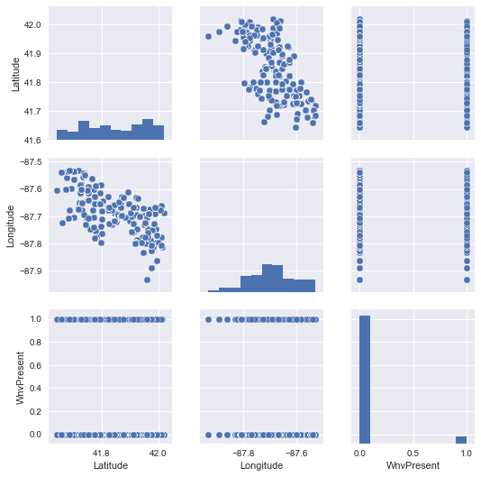

```python
no_dummies = [x for x in traps.columns if not 'Species_' in x]
sns.pairplot(traps[no_dummies])
```

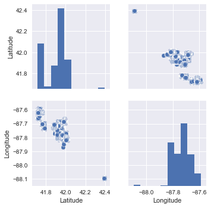

```python
sns.pairplot(spray)
```

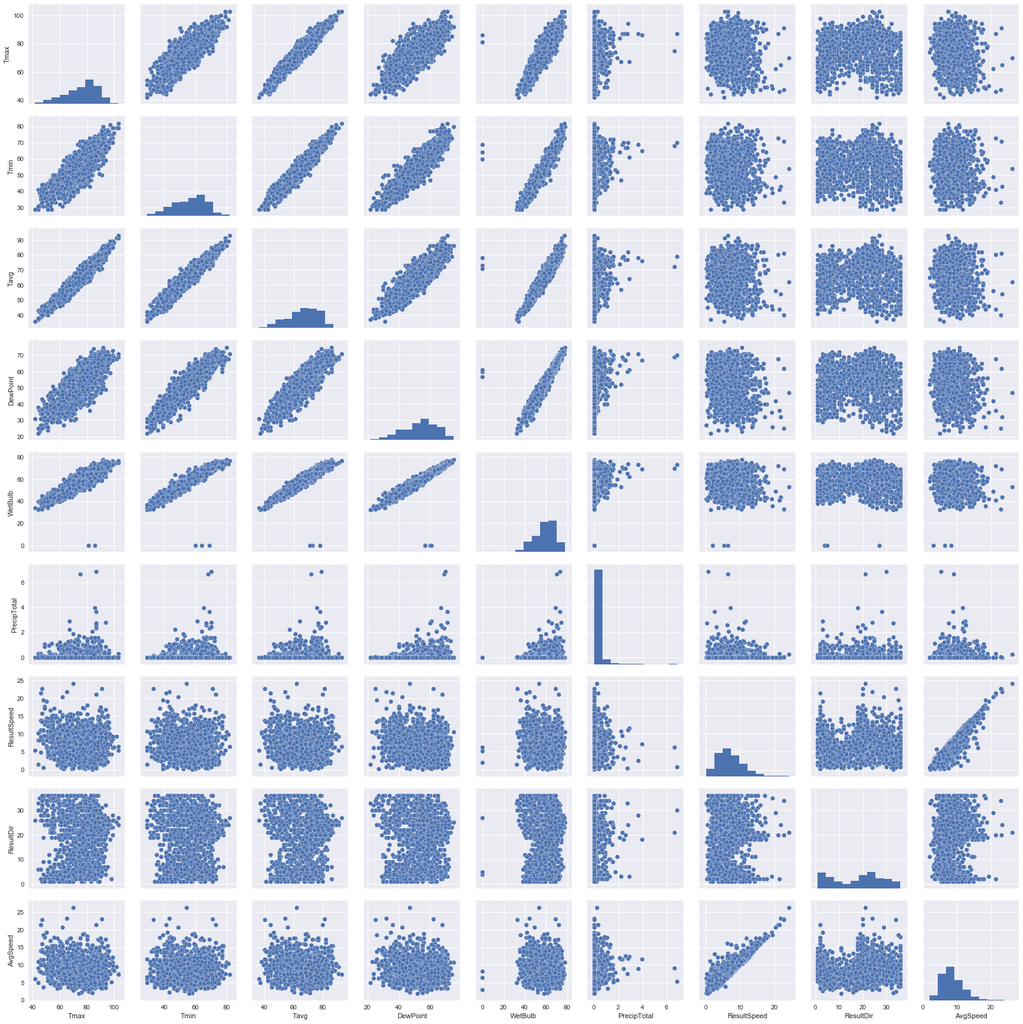

```python
no_dummies = weather.columns.drop(['CodeSum','SeaLevel','StnPressure'])
sns.pairplot(weather[no_dummies])
```

# Create More Features

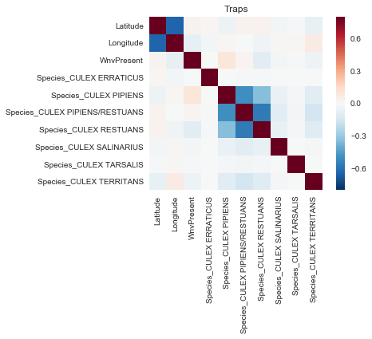

```python
#Before adding anything, let's see what the feature correlation looks like
def find_correlation(data,title):
    correlation = data.corr()
    sns.heatmap(correlation, vmax=.8, square=True)
    plt.title(title)

find_correlation(traps, 'Traps')
```

```python
## Parse Dates to see if they can be used in the modeling
traps['year']  = traps['Date'].dt.year
traps['month'] = traps['Date'].dt.month
traps['day']   = traps['Date'].dt.day
```

## Add Weather data

This function will add weather features to our traps df, and takes three arguments:

- the column name as a string from weather dataframe that we want to extract
- a numpy function that we want to do to the data
- an integer number of previous days to extract

```python
def weather_add(df, weather_col, func, days_range=7):
    new_list = []
    for i in df['Date']:
        mask = (weather['Date'] <= i) & (weather['Date'] >= i - pd.Timedelta(days=days_range))
        data_list = func(weather[weather_col][mask])
        new_list.append(data_list)
    return new_list
```

```python
## running this cell will extract the average temp min, average temp max, and precipitation sum
## to the traps dataframe from the previous 7 days, unless otherwise specified


for col in ['Tmax','Tmin','Tavg','WetBulb','CodeSum','StnPressure','SeaLevel', 'ResultSpeed', 'ResultDir','AvgSpeed']:
    traps[col] = weather_add(traps, weather_col=col, func=np.mean)

traps['PrecipTotal']= weather_add(traps, weather_col='PrecipTotal', func= np.sum)
traps['DewPoint']= weather_add(traps, weather_col ='DewPoint', func=np.mean, days_range = 10)

traps['Tmax_20'] = weather_add(traps, weather_col='Tmax',func=np.mean, days_range=20)
traps['Tmin_20'] = weather_add(traps, weather_col='Tmin', func=np.mean, days_range=20)

traps['Tmin_3']  = weather_add(traps, weather_col='Tmin', func=np.mean, days_range=3)
traps['Tmax_3']  = weather_add(traps, weather_col='Tmax', func=np.mean, days_range=3)
```

[output not shown]

## Add Spray data

```python
def add_cols(traps,start,stop,col,Spray_col):
    # ex) I want the week leading up to the inspection date: start = 0, end = 7
    # ex) I want the week before that: start = 7, end = 14
    from geopy.distance import vincenty
    traps_sprayed = traps[traps[Spray_col].isnull()].index.values
    remaining = len(traps_sprayed)

    for i in traps_sprayed:
        if start>0: # subtract # of days from the date the trap is inspected
            start_date = traps.Date.loc[i] - pd.Timedelta(days=start)
        else: # if start=0, then we're starting on the trap inspection day and collecting data backwards
            start_date = traps.Date.loc[i]
        end_date = traps.Date.loc[i] - pd.Timedelta(days=stop)
        dates = pd.date_range(start=end_date, end=start_date).tolist() # create list of all dates in our start, end points
        trap_lat = traps.Latitude.loc[i]
        trap_long = traps.Longitude.loc[i]
        dist = []

        # for each dated trap inspection, select only the spray records within the date range
        spray_temp = spray[['Latitude','Longitude','Date']][spray.Date.isin(dates)]

        remaining-=1 # counts how many records are left to process
        print str(remaining),' remaining'

        # run through each coordinate in the spray data and record the distance from our trap
        for j in range(0,len(spray_temp)):
            spray_lat = spray_temp.Latitude.iloc[j]
            spray_long = spray_temp.Longitude.iloc[j]
            a = (trap_lat, trap_long) # trap coordinates
            b = (spray_lat, spray_long) # spray coordinates
            dist.append(vincenty(a, b).miles) # calculate the distance between the points

        try:
            # set the spray value to the shortest distance
            traps[Spray_col].loc[i] = min(dist)
            dt = dist.index(min(dist))
            spray_dt = spray_temp.Date.iloc[dt]
            # record the number of days from inspection that the nearest spray occurred
            traps[col].loc[i] = pd.Timedelta(traps.Date.loc[i]-spray_dt).days
        except:
            pass
```

```python
# get the indicies of trap data that actually have spray data
traps_spray = traps[traps.Year.isin([2011,2013])]

# create the columns
traps_spray['Spray_Dist'] = np.NaN
traps_spray['Spray_Days_Ago'] = np.NaN

# week leading up to inspection
add_cols(traps_spray,0,7,'Spray_Days_Ago','Spray_Dist')
#one week out
add_cols(traps_spray,7,14,'Spray_Days_Ago','Spray_Dist')
# two weeks out
add_cols(traps_spray,14,21,'Spray_Days_Ago','Spray_Dist')
# three weeks out
add_cols(traps_spray,21,28,'Spray_Days_Ago','Spray_Dist')
# four weeks out
add_cols(traps_spray,28,35,'Spray_Days_Ago','Spray_Dist')
```

```python
# Check to see how many values we were able to fill in
traps['Spray'].isnull().sum()/float(len(traps['Spray']))
```

```python
traps.drop(['Spray_Dist','Spray_Days_Ago'],axis=1,inplace=True)
```

```python
## Save the transformed tables so we don't have to run the earlier cells
# traps.to_csv('./assets/Train_transformed/traps_jd.csv', encoding='utf-8', index=False)
```

```python
##re-import the altered traps file if re-running and want to skip steps above
# traps = pd.read_csv('./assets/Train_transformed/traps_jd.csv')
```

# Feature Selection

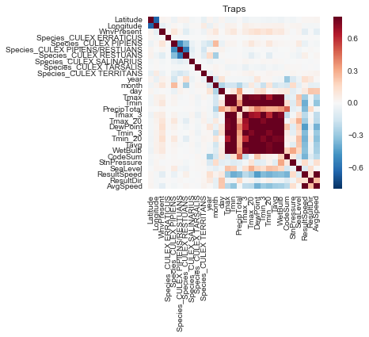

```python
## Check out how the correlation map changed with our new features
find_correlation(traps, 'Traps')
```

```python
X.columns
```

[output not shown]

```python
# Get rid of features that we cannot use
features = traps.columns.drop(['WnvPresent','Date','Trap'])

X = traps[features]
y = traps.WnvPresent
```

```python
## slightly adapted from: http://blog.datadive.net/selecting-good-features-part-iv-stability-selection-rfe-and-everything-side-by-side/

# from sklearn.feature_selection import SelectPercentile
from sklearn.linear_model import RandomizedLogisticRegression
from sklearn.feature_selection import RFECV, f_classif
from sklearn.preprocessing import StandardScaler
from sklearn.ensemble import RandomForestClassifier
import numpy as np

# create a function that scales the data, takes the data
# and scores the features, storing it in a dictionary, ranks
def rank_to_dict(ranks, names, order=1):
    minmax = StandardScaler()
    ranks = minmax.fit_transform(order*np.array([ranks]).T).T[0]
    ranks = map(lambda x: round(x, 2), ranks)
    return dict(zip(names, ranks ))

ranks = {}

lr = RandomizedLogisticRegression()
lr.fit(X, y)
ranks["Logistic"] = rank_to_dict(np.abs(lr.scores_), features)

rf = RandomForestClassifier()
rf.fit(X,y)
ranks["RF"] = rank_to_dict(rf.feature_importances_, features)

f, pval  = f_classif(X, y)
ranks["F_Classif."] = rank_to_dict(f, features)

r = {}
for name in features:
    r[name] = round(np.mean([ranks[method][name] for method in ranks.keys()]), 2)

methods = sorted(ranks.keys())

# average out the scores
ranks["Mean"] = r
methods.append("Mean")


# Now that we have our data, convert to dataframe for better viewing
feats = []
names = []

# feature names
for i in ranks['RF']:
    names.append(i)

feats.append(names)

# feature importances
for i in ranks:
    row = []
    for j in ranks[i]:
        row.append(ranks[i][j])
    feats.append(row)

feats_t = []

for i in range(0,len(features)):
    row = []
    for f in feats:
        row.append(f[i])
    feats_t.append(row)

feature_importances = pd.DataFrame(feats_t,columns = ['Feature','F_Classif','Logistic','RF','Mean'])
```

```python
feature_importances.sort_values(['Mean'],ascending=False)

# feature_importances.sort_values(['Mean','F_Classif','Logistic','RF'],ascending=False)
# feature_importances.Feature
```

|  | Feature | F_Classif | Logistic | RF | Mean |
| --- | --- | --- | --- | --- | --- |
| 18 | Longitude | 3.59 | 0.14 | 1.52 | 1.75 |
| 15 | DewPoint | -0.23 | 2.47 | 1.99 | 1.41 |
| 5 | Tmin_20 | -0.28 | 2.44 | 1.94 | 1.37 |
| 2 | month | -0.27 | 0.92 | 2.12 | 0.92 |
| 1 | Species_CULEX PIPIENS | -0.07 | 0.89 | 1.76 | 0.86 |
| 9 | Species_CULEX RESTUANS | -0.14 | 0.75 | 1.81 | 0.81 |
| 4 | Latitude | 3.60 | -0.79 | -0.63 | 0.73 |
| 10 | Tmax_20 | -0.26 | 1.25 | 0.06 | 0.35 |
| 16 | Tmin_3 | -0.30 | 0.90 | 0.24 | 0.28 |
| 20 | ResultSpeed | -0.27 | 0.54 | 0.09 | 0.12 |
| 6 | Tmin | -0.31 | 0.72 | -0.30 | 0.04 |
| 7 | WetBulb | -0.25 | 0.41 | -0.58 | -0.14 |
| 25 | AvgSpeed | -0.32 | 0.23 | -0.48 | -0.19 |
| 0 | Tavg | -0.29 | 0.16 | -0.63 | -0.25 |
| 26 | Tmax_3 | -0.31 | -0.07 | -0.63 | -0.34 |
| 17 | Tmax | -0.34 | -0.35 | -0.63 | -0.44 |
| 22 | Species_CULEX PIPIENS/RESTUANS | -0.02 | -0.91 | -0.63 | -0.52 |
| 3 | year | -0.32 | -0.62 | -0.63 | -0.52 |
| 8 | Species_CULEX TERRITANS | -0.35 | -0.69 | -0.63 | -0.56 |
| 27 | SeaLevel | -0.24 | -0.86 | -0.63 | -0.58 |
| 13 | CodeSum | -0.32 | -0.87 | -0.63 | -0.61 |
| 12 | StnPressure | -0.22 | -0.97 | -0.63 | -0.61 |
| 19 | Species_CULEX SALINARIUS | -0.36 | -0.87 | -0.63 | -0.62 |
| 11 | PrecipTotal | -0.32 | -0.94 | -0.63 | -0.63 |
| 21 | day | -0.32 | -0.98 | -0.63 | -0.64 |
| 14 | ResultDir | -0.33 | -0.96 | -0.63 | -0.64 |
| 23 | Species_CULEX TARSALIS | -0.38 | -0.97 | -0.63 | -0.66 |
| 24 | Species_CULEX ERRATICUS | -0.38 | -0.98 | -0.63 | -0.66 |

Cutting off the features at Tmin_3--use all above it. Also, this has been re-run several times and somehow the Species_CULEX RESTUANS shot up the ranks. This feature, however, wasn't used in any of our models, so it will not be included.

```python
features_new = list(feature_importances.sort_values(['Mean','F_Classif','Logistic','RF'],ascending=False)['Feature'][0:9])
features_new.remove('Species_CULEX RESTUANS')
```

```python
X = traps[features_new]
y = traps.WnvPresent
```

# Scale the Data

We will use the StandardScaler to scale our data for us in the RandomForest models and SVM models. We'll also just keep the regular data for comparison

```python
from sklearn.preprocessing import MinMaxScaler, StandardScaler, RobustScaler, normalize

X_s = pd.DataFrame(StandardScaler().fit_transform(X[X.columns.drop('Species_CULEX PIPIENS')]),columns=X.columns.drop('Species_CULEX PIPIENS'))
X_s = pd.DataFrame(X['Species_CULEX PIPIENS']).merge(X_s,left_on=X.index.values, right_on=X_s.index.values)
X_s.drop('key_0',inplace=True,axis=1)
```

# Train-Test Split

Creating a stratified train-test split to evaluate our models. Stratified because, as noted above, zeroes dominate WnvPositive at 94%.

```python
from sklearn.model_selection import train_test_split
```

Split the raw, unscaled data

```python
X_train, X_test, y_train, y_test = train_test_split(X,y,train_size=.33, stratify=y)
```

Split the scaled data

```python
X_train_s, X_test_s, y_train_s, y_test_s = train_test_split(X_s,y,train_size=.33, stratify=y)
```

Check that both sets have identical shape

```python
print 'Raw splits:'
print X_train.shape, X_test.shape, y_test.shape, y_train.shape
print
print 'Scaled splits:'
print X_train_s.shape, X_test_s.shape, y_test_s.shape, y_train_s.shape
```

```
Raw splits:
(2841, 8) (5769, 8) (5769,) (2841,)

Scaled splits:
(2841, 8) (5769, 8) (5769,) (2841,)
```

# Building the Models

Create a function that we will use to evaluate our models. It will return the ROC score that we can use to see how well it will do on Kaggle.

```python
from sklearn.metrics import roc_auc_score

def score_model(model,X_test,y_test):
    preds = model.predict_proba(X_test)
    pred_list =[]

    for x in preds:
        pred_list.append(x[1])

    roc_score = roc_auc_score(y_test, pred_list)
    return roc_score
```

## (1/6) Random Forest

```python
from sklearn.ensemble import RandomForestClassifier
from sklearn.model_selection import GridSearchCV

RF = RandomForestClassifier(n_estimators = 1000,
                            bootstrap=True,
                            max_depth=5,
                            max_features='auto',
                            min_samples_leaf= 1,
                            min_samples_split= 2)
```

Using raw data

```python
RF_model= RF.fit(X_train, y_train)
score_model(RF_model,X_test,y_test)
# 0.86780509496634572
```

```
0.82547715528947552
```

Using StandardScaled data

```python
RF_model_s = RF.fit(X_train_s, y_train_s)
score_model(RF_model_s,X_test_s, y_test_s)
# 0.81161294220537694
```

```
0.82209462587890736
```

## (2/6) Support Vector Machine

```python
from sklearn.svm import SVC
```

SVM with kernel = 'rbf'

```python
svmc= SVC(probability=True)
svm_model = svmc.fit(X_train,y_train)
score_model(svm_model,X_test,y_test)
# 0.30215737665155207
```

```
0.29652750110966347
```

```python
svm_model_s = svmc.fit(X_train_s,y_train_s)
score_model(svm_model_s,X_test_s,y_test_s)
```

```
0.7412381451451775
```

Scaled data performed significantly better.

Try with the linear kernel by using bagging and ovr

```python
# credit: first answer on http://stackoverflow.com/questions/31681373/making-svm-run-faster-in-python

import time
import numpy as np
from sklearn.ensemble import BaggingClassifier, RandomForestClassifier
from sklearn import datasets
from sklearn.multiclass import OneVsRestClassifier
from sklearn.svm import SVC


start = time.time()
clf1 = OneVsRestClassifier(SVC(kernel='linear', probability=True, class_weight='balanced'))
clf1.fit(X_train, y_train)
end = time.time()
print "Single SVC", end - start, clf1.score(X_test,y_test), score_model(clf1,X_test,y_test)

n_estimators = 10
start = time.time()
clf2 = OneVsRestClassifier(BaggingClassifier(SVC(kernel='linear', probability=True, class_weight='balanced'), max_samples=1.0 / n_estimators, n_estimators=n_estimators))
clf2.fit(X_train, y_train)
end = time.time()
print "Bagging SVC", end - start, clf2.score(X_test,y_test), score_model(clf2,X_test,y_test)


# Single SVC 4.18354606628 0.671693534408 0.754635462093
# Bagging SVC 0.904535055161 0.787831513261 0.746318070825
```

```
Single SVC 3.76783299446 0.655746229849 0.764287440524
Bagging SVC 0.574933052063 0.768070722829 0.752589015349
```

Try with the scaled data

```python
# credit: first answer on http://stackoverflow.com/questions/31681373/making-svm-run-faster-in-python

import time
import numpy as np
from sklearn.ensemble import BaggingClassifier, RandomForestClassifier
from sklearn import datasets
from sklearn.multiclass import OneVsRestClassifier
from sklearn.svm import SVC


start = time.time()
clf1s = OneVsRestClassifier(SVC(kernel='linear', probability=True, class_weight='balanced'))
clf1s.fit(X_train_s, y_train_s)
end = time.time()
print "Single SVC", end - start, clf1s.score(X_test_s,y_test_s), score_model(clf1s,X_test_s,y_test_s)

n_estimators = 10
start = time.time()
clf2s = OneVsRestClassifier(BaggingClassifier(SVC(kernel='linear', probability=True, class_weight='balanced'), max_samples=1.0 / n_estimators, n_estimators=n_estimators))
clf2s.fit(X_train_s, y_train_s)
end = time.time()
print "Bagging SVC", end - start, clf2s.score(X_test_s,y_test_s), score_model(clf2s,X_test_s,y_test_s)


# Single SVC 1.21880817413 0.680013867221 0.751182644026
# Bagging SVC 0.137820005417 0.718495406483 0.744525261444
```

```
Single SVC 1.31022405624 0.648812619171 0.772368542267
Bagging SVC 0.167356967926 0.73565609291 0.762660332911
```

## (3/6) Logistic Regression

```python
#LOGISTIC REGRESSION
from sklearn import metrics
from sklearn.linear_model import LogisticRegression
from sklearn.model_selection import cross_val_score
def log(X,y,X_test,y_test):
    # flatten y into a 1-D array
    y_log = np.ravel(y)
    model = LogisticRegression()
    model = model.fit(X, y)
    predicted = model.predict(X_test)
    probs = model.predict_proba(X_test)
    scores = cross_val_score(LogisticRegression(), X, y, scoring='accuracy', cv=10)
    print 'Mean CV score: ' + str(scores.mean())
    print 'Accuracy score: ' + str(metrics.accuracy_score(y_test, predicted))
    print 'Roc-auc score: ' + str(metrics.roc_auc_score(y_test, probs[:, 1]))
    print ''
    print 'Confusion matrix: \n' + str(metrics.confusion_matrix(y_test, predicted))
    print 'Classification report: \n' + str(metrics.classification_report(y_test, predicted))
    # check the accuracy on the training set
    print 'Model score: ' + str(model.score(X_test, y_test))
    print 'Kaggle: ' + str(score_model(model,X_test,y_test))
    print ''


log(X_train,y_train,X_test,y_test)
log(X_train_s,y_train_s,X_test_s,y_test_s)


# Mean CV score: 0.946850753645
# Accuracy score: 0.946957878315
# Roc-auc score: 0.734609476227

# Mean CV score: 0.946850753645
# Accuracy score: 0.946957878315
# Roc-auc score: 0.761849471011
```

```
Mean CV score: 0.946850753645
Accuracy score: 0.946957878315
Roc-auc score: 0.747154356282

Confusion matrix:
[[5463    0]
 [ 306    0]]
Classification report:
             precision    recall  f1-score   support

          0       0.95      1.00      0.97      5463
          1       0.00      0.00      0.00       306

avg / total       0.90      0.95      0.92      5769

Model score: 0.946957878315
Kaggle: 0.747154356282

Mean CV score: 0.946850753645
Accuracy score: 0.946957878315
Roc-auc score: 0.768921108012

Confusion matrix:
[[5463    0]
 [ 306    0]]
Classification report:
             precision    recall  f1-score   support

          0       0.95      1.00      0.97      5463
          1       0.00      0.00      0.00       306

avg / total       0.90      0.95      0.92      5769

Model score: 0.946957878315
Kaggle: 0.768921108012
```

The logistic regression model using the scaled data looks okay. Making that model and submitting to kaggle.

```python
# flatten y into a 1-D array
y_log = np.ravel(y_train_s)
log_model = LogisticRegression()
log_model = log_model.fit(X_train_s, y_train_s)
```

## (4/6) ADA Boost

```python
from sklearn.ensemble import AdaBoostClassifier
```

```python
adaboost= AdaBoostClassifier()
ada_model=adaboost.fit(X,y)
score_model(ada_model,X_test,y_test)
#0.88491183862121936
```

```
0.85638831162460716
```

## (5/6) Gradient Boost

```python
from sklearn.ensemble import GradientBoostingClassifier

def GradBoostClass(X_train,y_train,X_test,y_test):
    clf = GradientBoostingClassifier(n_estimators=100, learning_rate=1.0,max_depth=1, random_state=0).fit(X_train, y_train)
    clf.score(X_test, y_test)
    print score_model(clf,X_test,y_test)
    print ''

GradBoostClass(X_train,y_train,X_test,y_test)
GradBoostClass(X_train_s,y_train_s,X_test_s,y_test_s)
# 0.807420448196

# 0.799875933045
```

```
0.820344288792

0.821106397285
```

```python
gradboost = GradientBoostingClassifier(n_estimators=100, learning_rate=1.0,max_depth=1, random_state=0).fit(X_train, y_train)
gradboost.score(X_test, y_test)
```

```
0.94661119778124458
```

## (6/6) XG Boost

```python
import xgboost as xgb
from xgboost.sklearn import XGBClassifier
import scipy.stats as st

model = XGBClassifier()
xgm = model.fit(X_train, y_train, eval_metric=roc_auc_score)
score_model(xgm,X_test,y_test)
# 0.8723832880791802
```

```
0.82574036387390393
```

### 6a) XGBoost GridSearch

```python
import random

params = {
    "n_estimators": [3,4,5,7,8,10],
    "max_depth": st.randint(3, 40),
    "learning_rate": st.uniform(0.05, 0.4),
    'eval_metric' :'auc',
    'objective': ['binary:logistic']
}

xgbclass = XGBClassifier()
```

```python
from sklearn.model_selection import RandomizedSearchCV

gs = GridSearchCV(xgbclass,  params, n_jobs=-1, scoring='roc_auc')
gs.fit(X_train, y_train)

gs.best_estimator_
```

```python
xg_grid = XGBClassifier(base_score=0.5, colsample_bylevel=1, colsample_bytree=1,
       gamma=0, learning_rate=0.1, max_delta_step=0, max_depth=3,
       min_child_weight=1, missing=None, n_estimators=100, nthread=-1,
       objective='binary:logistic', reg_alpha=0, reg_lambda=1,
       scale_pos_weight=1, seed=0, silent=True, subsample=1)

xg_final = xg_grid.fit(X_train, y_train)
score_model(xg_final,X_test,y_test)
# 0.81860621483323937
```

```
0.82574036387390393
```

# Import and Transform Test Data

```python
## Add features
test['Tmax_20'] = weather_add(test, weather_col='Tmax',func=np.mean, days_range=20)
test['DewPoint']= weather_add(test, weather_col ='DewPoint', func=np.mean, days_range = 10)
test['Tmin_3'] = weather_add(test, weather_col='Tmin', func=np.mean, days_range=3)
test['Tmin_20'] = weather_add(test, weather_col='Tmin', func=np.mean, days_range=20)

test['month'] = test['Date'].dt.month
```

```python
## Export the tranformed test data to a folder in the repo
## so we don't have to run the above cells every time

# test.to_csv('./assets/Test_transformed/test_transformed_427.csv',sep=',', encoding='utf-8')
```

```python
# test = pd.read_csv('./assets/Test_transformed/test_transformed_427.csv')
```

```python
test_X = test[features_new]
```

```python
test_s = pd.DataFrame(StandardScaler().fit_transform(test_X[test_X.columns.drop(['Species_CULEX PIPIENS'])]),columns=test_X.columns.drop(['Species_CULEX PIPIENS']))
test_s = pd.DataFrame(test_X[['Species_CULEX PIPIENS']]).merge(test_s,left_on=test_X.index.values, right_on=test_s.index.values)
test_s.drop('key_0',inplace=True,axis=1)
```

# Exporting to test

```python
###This function will takes a model and a model name(as a string), generate predictions,
### and save that as a CSV labeled with the model name and date.
import time
import math
def model_and_export(model, model_name,test_X=test_X):
    pred_list = []
    predictions =  model.predict_proba(test_X)
    for x in predictions:
        pred_list.append(x[1])
    indexes=np.arange(1, len(predictions)+1, 1)
    preds_df = pd.DataFrame(data=[indexes, pred_list]).T
    preds_df.columns =['Id','WnvPresent']
    preds_df['Id'] = preds_df.Id.astype(int)
    location = './submissions/{}_{}.csv'.format(model_name, time.strftime("%d_%m_%Y"))
    preds_df.to_csv(location, index=False)
    return
```

```python
model_and_export(RF_model, 'RF_JD*')
# Your submission scored 0.72874
```

```python
model_and_export(log_model, 'LOG_JD*',test_s)
# Your submission scored 0.72305
```

```python
model_and_export(clf2s, 'SVM_S*', test_s)
# Your submission scored 0.69906.
```

```python
model_and_export(ada_model, 'ADABoost_JD*')
# Your submission scored 0.74416.
```

```python
model_and_export(gradboost, 'GRADBOOST_*')
# Your submission scored 0.64589
```

```python
model_and_export(xgm, 'XG_JD*')
# Your submission scored 0.75110
```

```python
model_and_export(xg_final, 'XG_FINAL*')
# Your submission scored 0.71567
```

### Ensembles

```python
def ensemble_and_export(model1,model2,test_X,file_name):
    pred_m1 = []
    predictions_m1 =  model1.predict_proba(test_X)
    pred_m2 = []
    predictions_m2 =  model2.predict_proba(test_X)

    for x in predictions_m1:
        pred_m1.append(x[1])

    for x in predictions_m2:
        pred_m2.append(x[1])

    indexes=np.arange(1, len(predictions_m1)+1, 1)

    preds_m1 = pd.DataFrame(data=[indexes, pred_m1]).T
    preds_m1.columns =['Id','WnvPresent']
    preds_m1['Id'] = preds_m1.Id.astype(int)

    preds_m2 = pd.DataFrame(data=[indexes, pred_m2]).T
    preds_m2.columns =['Id','WnvPresent']
    preds_m2['Id'] = preds_m2.Id.astype(int)

    ensemble = preds_m1.merge(preds_m2,left_on='Id', right_on='Id')

    ensemble['avg'] = (ensemble['WnvPresent_x']+ ensemble['WnvPresent_y']) / 2
    ensemble.rename(columns={'avg':'WnvPresent'},inplace=True)

    ensemble = ensemble[['Id','WnvPresent']]

    location = './submissions/{}_{}.csv'.format(file_name, time.strftime("%d_%m_%Y"))
    ensemble.to_csv(location, index=False)
```

```python
ensemble_and_export(xgm,ada_model,test_X,'Ensemble_XG_ADA*')
# Your submission scored 0.70831.
```

```python
ensemble_and_export(xgm,RF_model_s,test_X,'Ensemble_XG_RF*')
# Your submission scored 0.70979.
```